# load data

```python
import pandas as pd

UserActivity = pd.read_csv('https://storage.googleapis.com/datalynn-datasets/interview-challenge/technology/microsoft_1/UserActivity.csv')
UserDetails = pd.read_csv('https://storage.googleapis.com/datalynn-datasets/interview-challenge/technology/microsoft_1/UserDetails.csv')
ChannelDetails = pd.read_csv('https://storage.googleapis.com/datalynn-datasets/interview-challenge/technology/microsoft_1/ChannelDetails.csv')
```

### **Question 1:** (Topics: Data Science and Analysis, Probability and Statistics)

- Given the UserActivity data, calculate the probability of a user logging in at least once during peak hours (9 AM - 5 PM). How does this probability vary across different roles and locations?

### Solution:

```python
# Convert 'Login Time' and 'Logout Time' to datetime
UserActivity['Login Time'] = pd.to_datetime(UserActivity['Login Time'])
UserActivity['Logout Time'] = pd.to_datetime(UserActivity['Logout Time'])

# Create a new column 'Peak Login' to identify if the login time is during peak hours (9 AM - 5 PM)
UserActivity['Peak Login'] = ((UserActivity['Login Time'].dt.hour >= 9) & (UserActivity['Login Time'].dt.hour < 17))

# Merge UserActivity and UserDetails dataframes
merged_df = pd.merge(UserActivity, UserDetails, on='User ID')

# Calculate the probability of a user logging in at least once during peak hours
total_users = merged_df['User ID'].nunique()
peak_users = merged_df[merged_df['Peak Login'] == True]['User ID'].nunique()
probability_peak_login = peak_users / total_users
print(f"Overall Probability of a user logging in at least once during peak hours: {probability_peak_login}")

# Calculate the probability across different roles
for role in merged_df['Role'].unique():
    total_role_users = merged_df[merged_df['Role'] == role]['User ID'].nunique()
    peak_role_users = merged_df[(merged_df['Peak Login'] == True) & (merged_df['Role'] == role)]['User ID'].nunique()
    probability_role_peak_login = peak_role_users / total_role_users
    print(f"Probability of a {role} logging in at least once during peak hours: {probability_role_peak_login}")

# Calculate the probability across different locations
for location in merged_df['Location'].unique():
    total_location_users = merged_df[merged_df['Location'] == location]['User ID'].nunique()
    peak_location_users = merged_df[(merged_df['Peak Login'] == True) & (merged_df['Location'] == location)]['User ID'].nunique()
    probability_location_peak_login = peak_location_users / total_location_users
    print(f"Probability of a user from {location} logging in at least once during peak hours: {probability_location_peak_login}")
```

```
Overall Probability of a user logging in at least once during peak hours: 0.99
Probability of a manager logging in at least once during peak hours: 1.0
Probability of a developer logging in at least once during peak hours: 1.0
Probability of a analyst logging in at least once during peak hours: 0.9666666666666667
Probability of a user from San Francisco logging in at least once during peak hours: 1.0
Probability of a user from Remote logging in at least once during peak hours: 1.0
Probability of a user from Seattle logging in at least once during peak hours: 0.9743589743589743
```

### **Question 2:** (Topics: Machine Learning and Modeling, Data Science and Analysis)

- Using the UserActivity and UserDetails data, build a predictive model to forecast user engagement (measured by Activity Duration) for the next week. What features would you consider for this model? Explain the bias-variance tradeoff in the context of your model.

### Solution:

```python
from sklearn.model_selection import train_test_split
from sklearn.ensemble import RandomForestRegressor
from sklearn.metrics import mean_squared_error
import numpy as np

# Merge UserActivity and UserDetails dataframes
merged_df = pd.merge(UserActivity, UserDetails, on='User ID')

# Create new features
merged_df['Login Hour'] = merged_df['Login Time'].dt.hour
merged_df['Day of Week'] = merged_df['Login Time'].dt.dayofweek
merged_df['Is Weekend'] = np.where(merged_df['Day of Week'].isin([5, 6]), 1, 0)

# One-hot encode categorical features
merged_df = pd.get_dummies(merged_df, columns=['Role', 'Location', 'Activity Type'])

# Define target variable
y = merged_df['Activity Duration']

# Define feature variables
X = merged_df.drop(['User ID', 'Login Time', 'Logout Time', 'Team ID', 'Channel ID', 'Activity Duration', 'Joining Date'], axis=1)

# Split the data into training and test sets
X_train, X_test, y_train, y_test = train_test_split(X, y, test_size=0.2, random_state=42)

# Initialize the model
model = RandomForestRegressor(n_estimators=100, random_state=42)

# Fit the model
model.fit(X_train, y_train)

# Make predictions
y_pred = model.predict(X_test)

# Calculate RMSE
rmse = np.sqrt(mean_squared_error(y_test, y_pred))
print(f"RMSE: {rmse}")
```

```
RMSE: 19.485977890292688
```

### **Question 3:** (Topics: Data Science and Analysis, Coding and Programming)

- Implement a function in Python that identifies the top 5 most active channels (based on total Activity Duration) for each team.

### Solution:

```python
# Group by 'Team ID' and 'Channel ID', sum 'Activity Duration'
grouped_df = UserActivity.groupby(['Team ID', 'Channel ID'])['Activity Duration'].sum().reset_index()

# Sort by 'Activity Duration' and select top 5 channels for each team
top_channels = grouped_df.groupby('Team ID').apply(lambda x: x.nlargest(5, 'Activity Duration')).reset_index(drop=True)

print(top_channels)
```

```
    Team ID  Channel ID  Activity Duration
0         1          13                172
1         1           9                156
2         1          18                155
3         1          46                151
4         1          17                143
5         2          11                169
6         2          14                150
7         2          32                131
8         2          49                131
9         2           6                125
10        3          26                223
11        3          23                180
12        3          49                175
13        3          24                152
```

[output cut: 36 more lines]

### **Question 4:** (Topics: Machine Learning and Modeling, Data Science and Analysis)

- Using the output from Question 3 and the ChannelDetails data, can you identify any patterns or anomalies in the most active channels? For instance, are certain types of channels more active than others?

### Solution:

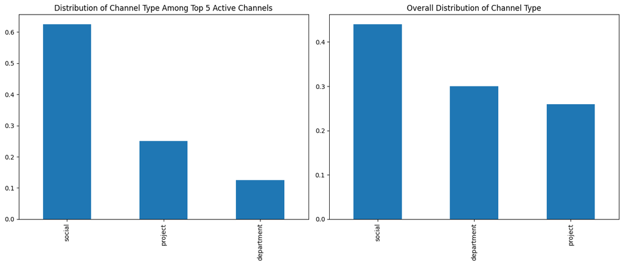

```python
# Assuming the previous code has been executed and top_channels dataframe is available

# Merge top_channels with ChannelDetails to get the Channel Type
merged_top_channels = pd.merge(top_channels, ChannelDetails, on=['Channel ID', 'Team ID'])

# Distribution of Channel Type among the top 5 most active channels
top_channel_types = merged_top_channels['Channel Type'].value_counts(normalize=True)

# Overall distribution of Channel Type
overall_channel_types = ChannelDetails['Channel Type'].value_counts(normalize=True)

# Plotting the distributions
fig, ax = plt.subplots(1, 2, figsize=(14, 6))

top_channel_types.plot(kind='bar', ax=ax[0], title='Distribution of Channel Type Among Top 5 Active Channels')
overall_channel_types.plot(kind='bar', ax=ax[1], title='Overall Distribution of Channel Type')

plt.tight_layout()
plt.show()
```

### **Question 5:** (Topics: Social and Communication, Job-related)

- Based on your findings from the previous questions, propose a strategy to improve user engagement on Teams and Channels. How would you communicate these findings and your proposed strategy to a non-technical stakeholder?

### Solution:

For Question 5, we need to propose a strategy to improve user engagement on Teams and Channels based on our findings from the previous questions. We also need to consider how to communicate these findings and our proposed strategy to a non-technical stakeholder.

Based on the findings from the previous questions, a possible strategy could be to focus on promoting the use of Teams and Channels during peak hours, as this is when users are most active. We could also provide additional resources or training for certain roles or locations if they have lower engagement levels. If certain types of channels are more active than others, we could encourage the creation of more channels of these types.

To communicate these findings and our proposed strategy to a non-technical stakeholder, we would need to explain our findings in simple, non-technical terms. We could use visual aids like graphs and charts to illustrate our findings. We would also need to clearly explain the benefits of our proposed strategy and how it would help to improve user engagement and productivity.

Python Code:

While there is no specific Python code to answer this question, we can use Python to create visualizations that can help to communicate our findings. For example, we could create a bar chart showing the average activity duration for each role or location, or a pie chart showing the proportion of activity that occurs during peak hours.

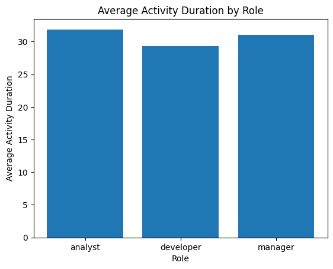

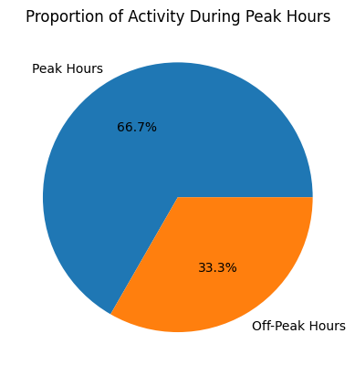

```python
import matplotlib.pyplot as plt

# Calculate average activity duration for each role

merged_df = pd.merge(UserActivity, UserDetails, on='User ID')
avg_duration_role = merged_df.groupby('Role')['Activity Duration'].mean()

# Create bar chart
plt.bar(avg_duration_role.index, avg_duration_role.values)
plt.xlabel('Role')
plt.ylabel('Average Activity Duration')
plt.title('Average Activity Duration by Role')
plt.show()

# Calculate proportion of activity during peak hours
peak_activity = merged_df['Peak Login'].value_counts(normalize=True)

# Create pie chart
plt.pie(peak_activity.values, labels=['Peak Hours', 'Off-Peak Hours'], autopct='%1.1f%%')
plt.title('Proportion of Activity During Peak Hours')
plt.show()
```